# Exploring Patterns and Dynamics of Mouses’ Neurons

We are continued to explore the neural activity patterns in Session 2. As we visualize the wide view of overall neural activity over the trials, we are going to change a point of view and now on we will concentrate on a specific trial. We are going to build a plot that visualize the activities of all neurons during a specific trial which will be trial 1 Session 2.

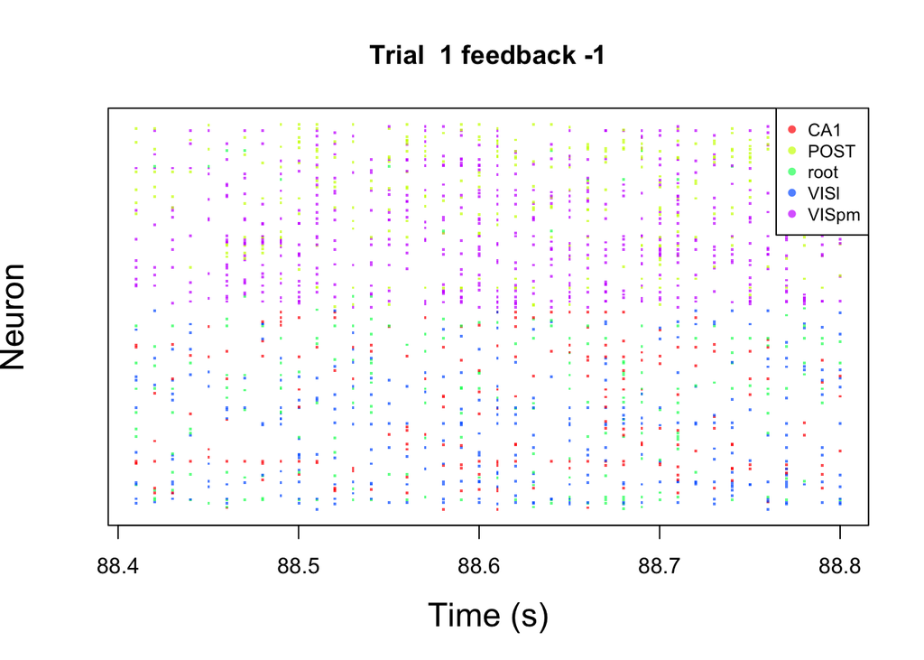

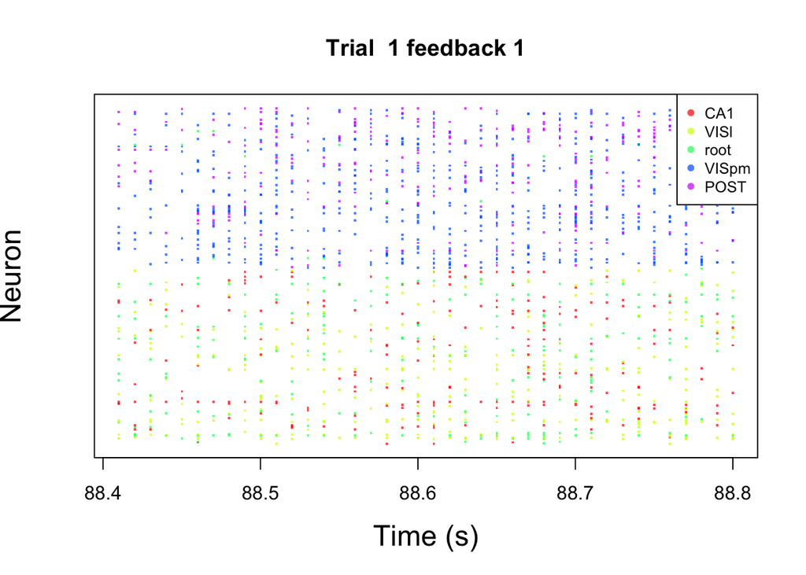

# Trial 2 for feedback +1 and -1

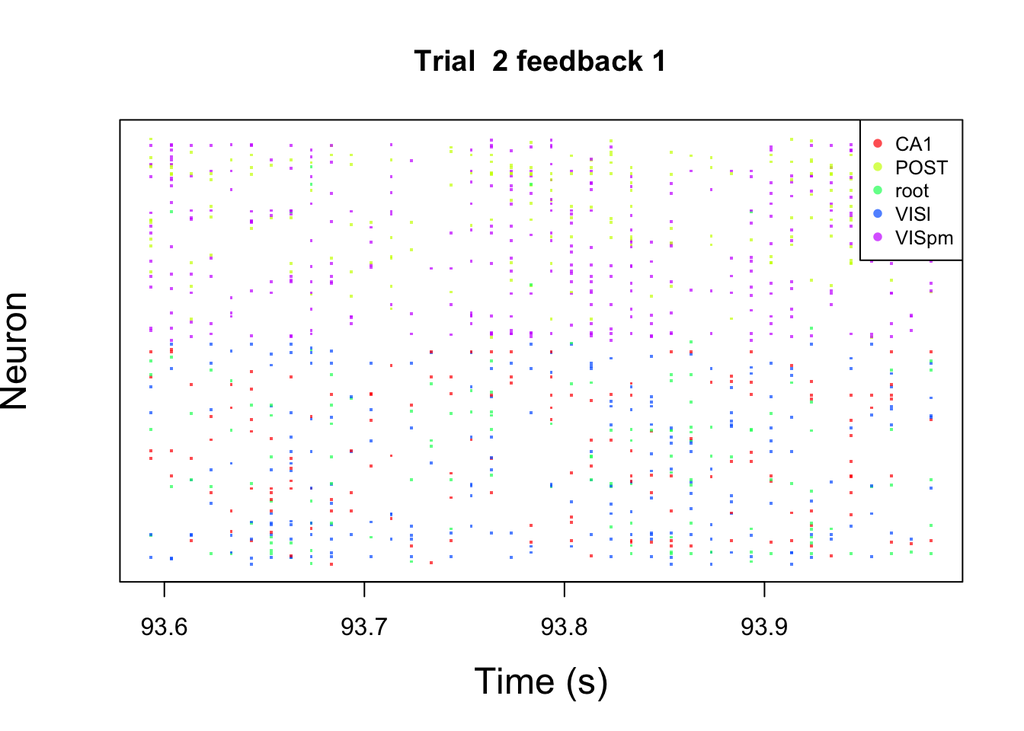

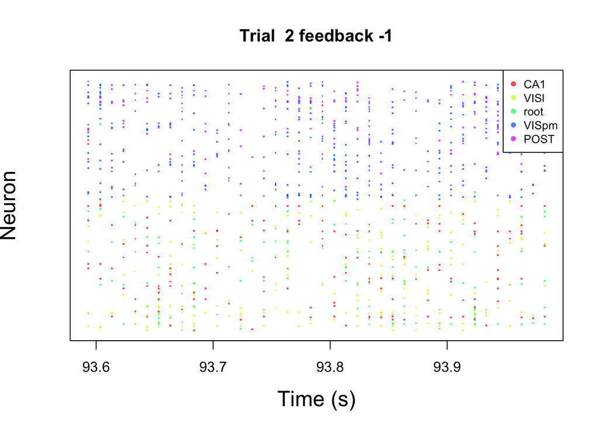

In this section, we are going to explore the homogeneity and heterogeneity across sessions and mice. In order to examine the homogeneity and heterogeneity of neural activity, we are going to see whether the average spike counts is consistent throughout the sessions and following trials so that we can see the similarities and differences in the data.

```
## Average Spike Counts:
```

```
## Session 1 :  1130.096
## Session 2 :  1354.227
## Session 3 :  1382.807
## Session 4 :  1488.711
## Session 5 :  1201.748
## Session 6 :  775.269
## Session 7 :  826.5794
## Session 8 :  1915.492
## Session 9 :  1250.847
## Session 10 :  1391.792
## Session 11 :  1071.67
## Session 12 :  1160.959
## Session 13 :  2415.9
## Session 14 :  760.9963
## Session 15 :  1087.814
## Session 16 :  497.8786
## Session 17 :  658.683
## Session 18 :  1195.12
```

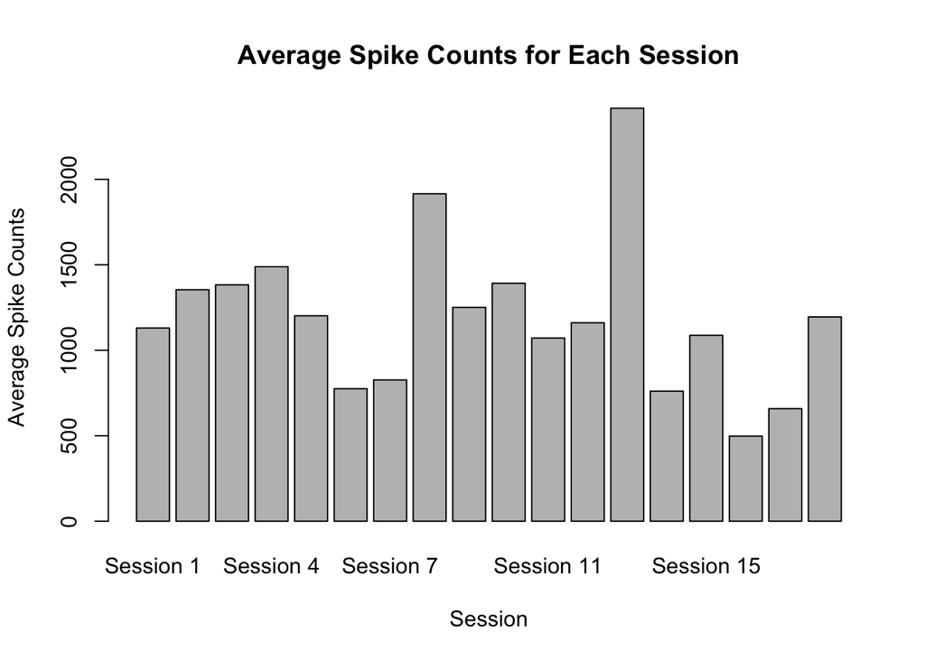

In this plot, we can distinguish that there are two highest sessions that has the relatively high average spike counts - Session 8 and Session 13. However, Session 6,7,14,16,17 seems to have relatively low average spike counts that they seem to have counts that is below the 1000. Box Plot can visualize the distribution of average spike counts for each session. It seems like Session 1 through Session 5 has the similar average spike counts, and thus it shows the high level of homogeneity across those sessions.

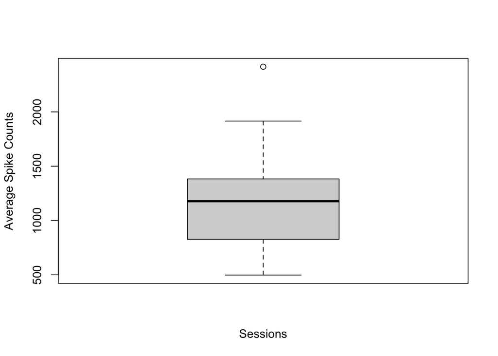

```
##    Min. 1st Qu.  Median    Mean 3rd Qu.    Max.
##   474.0   707.0   822.5   905.8  1086.8  1769.0
```

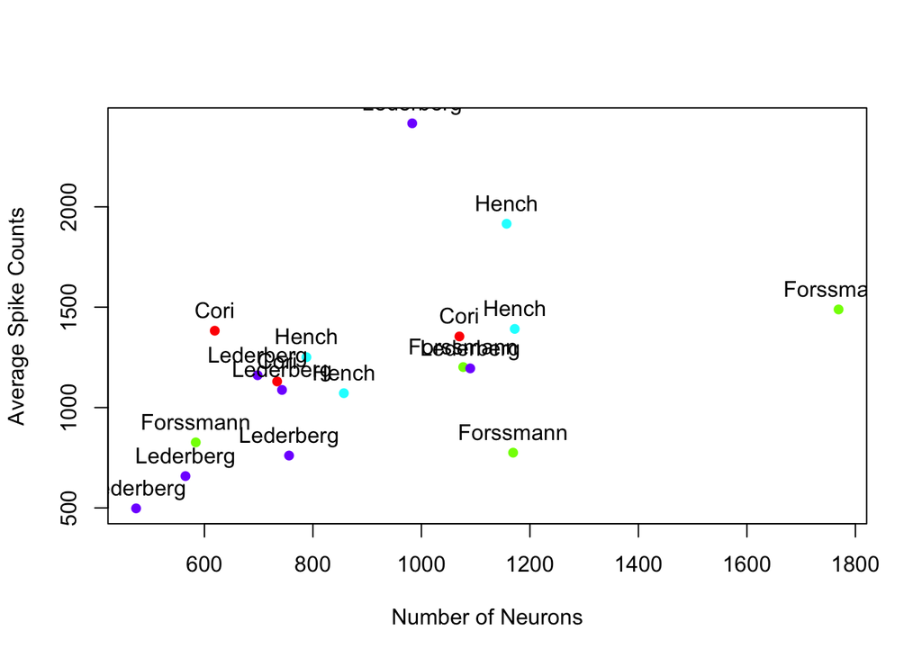

In this plot, it shows the relationship between the number of neurons and average spike counts across the 18 sessions from four mice: Cori, Forssmann, Hence and Lederberg. In terms of heterogeneity, we can observe that even the mice with the same name has different numbers for number of neurons and so as average spike counts. This plot supports the strongness of the heterogeneity that the number of neurons and the average spike counts are pretty much all over the place.

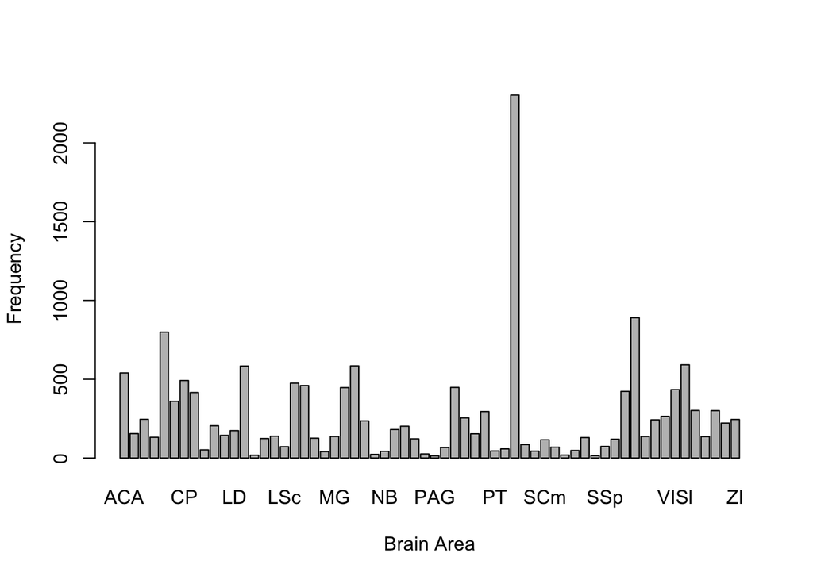

```
## # A tibble: 4 × 3
##   mechanism      avg_success_rate total_trials
##   <chr>                     <dbl>        <int>
## 1 Equal Contrast            0.505          315
## 2 Left > Right              0.499         1762
## 3 No Contrast               0.521         1371
## 4 Right > Left              0.512         1633
```

To extract the shared patters across sessions and address the difference between session, we are going to combine the data across the trials and sessions in the experiments. PCA plot shows clusters of samples based on their similarity. PCA aims to capture the important flows and the distribution in the data by changing it into a new set of variables called PC. The very first PC is the maximum amount of variance in the data, and PC2 explains the second most variance, and so on.

```
## Importance of components:
##                           PC1    PC2     PC3     PC4     PC5     PC6     PC7
## Standard deviation     0.5091 0.2243 0.20354 0.19115 0.18592 0.18267 0.17947
## Proportion of Variance 0.1772 0.0344 0.02832 0.02498 0.02363 0.02281 0.02202
## Cumulative Proportion  0.1772 0.2116 0.23991 0.26488 0.28851 0.31132 0.33334
##                            PC8     PC9    PC10    PC11   PC12    PC13    PC14
## Standard deviation     0.17931 0.17891 0.17825 0.17772 0.1774 0.17670 0.17642
## Proportion of Variance 0.02198 0.02188 0.02172 0.02159 0.0215 0.02134 0.02128
## Cumulative Proportion  0.35532 0.37720 0.39892 0.42051 0.4420 0.46335 0.48463
##                           PC15    PC16    PC17    PC18   PC19    PC20    PC21
## Standard deviation     0.17632 0.17576 0.17510 0.17489 0.1745 0.17410 0.17372
## Proportion of Variance 0.02125 0.02112 0.02096 0.02091 0.0208 0.02072 0.02063
## Cumulative Proportion  0.50588 0.52700 0.54795 0.56886 0.5897 0.61039 0.63102
##                           PC22    PC23    PC24    PC25    PC26    PC27    PC28
## Standard deviation     0.17326 0.17278 0.17255 0.17249 0.17227 0.17156 0.17131
## Proportion of Variance 0.02052 0.02041 0.02035 0.02034 0.02029 0.02012 0.02006
## Cumulative Proportion  0.65153 0.67194 0.69229 0.71263 0.73292 0.75304 0.77310
##                           PC29    PC30    PC31    PC32    PC33    PC34    PC35
## Standard deviation     0.17116 0.17076 0.17008 0.16939 0.16828 0.16763 0.16709
## Proportion of Variance 0.02003 0.01993 0.01977 0.01961 0.01936 0.01921 0.01908
## Cumulative Proportion  0.79312 0.81306 0.83283 0.85244 0.87180 0.89101 0.91009
##                           PC36   PC37    PC38    PC39    PC40
## Standard deviation     0.16477 0.1632 0.16250 0.16053 0.15990
## Proportion of Variance 0.01856 0.0182 0.01805 0.01762 0.01748
## Cumulative Proportion  0.92865 0.9469 0.96491 0.98252 1.00000
```

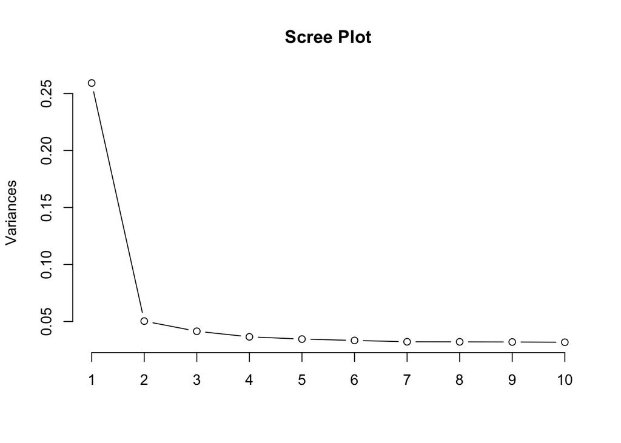

The first principal component (PC1) has the highest standard deviation and explains the highest proportion of variance (0.1772). The cumulative portion of variance. The cumulative proportion of variance is 17.72% of the total variance. Scree Plot is the plot to visualize the proportion of variance explained by each principal component. It shows the porportion of variance explained by each principal component. This allows us to determine the number of principal components to retain for further analysis. I this case, we can see that the first principal component explain a large portion of the variance in the data. The result shows that PC1 accounts for the most important pattern in the data, and can be used to summarize the data in a more simplified way.

```
## Session: 1
## Mouse Name: Cori
## Same Mouse Sessions: 1 2 3
##
## Session: 2
## Mouse Name: Cori
## Same Mouse Sessions: 1 2 3
##
## Session: 3
## Mouse Name: Cori
## Same Mouse Sessions: 1 2 3
##
## Session: 4
## Mouse Name: Forssmann
## Same Mouse Sessions: 4 5 6 7
##
## Session: 5
## Mouse Name: Forssmann
## Same Mouse Sessions: 4 5 6 7
##
## Session: 6
## Mouse Name: Forssmann
## Same Mouse Sessions: 4 5 6 7
##
## Session: 7
## Mouse Name: Forssmann
## Same Mouse Sessions: 4 5 6 7
##
## Session: 8
## Mouse Name: Hench
## Same Mouse Sessions: 8 9 10 11
##
## Session: 9
## Mouse Name: Hench
## Same Mouse Sessions: 8 9 10 11
##
## Session: 10
## Mouse Name: Hench
## Same Mouse Sessions: 8 9 10 11
##
```

[output cut: 16 more lines]

```
## Session: 15
## Mouse Name: Lederberg
## Same Mouse Sessions: 12 13 14 15 16 17 18
##
## Session: 16
## Mouse Name: Lederberg
## Same Mouse Sessions: 12 13 14 15 16 17 18
##
## Session: 17
## Mouse Name: Lederberg
## Same Mouse Sessions: 12 13 14 15 16 17 18
##
## Session: 18
## Mouse Name: Lederberg
## Same Mouse Sessions: 12 13 14 15 16 17 18
```

In this data, we know: Mouse: Cori Session IDs: 1, 2, 3 Same Mouse Sessions: 1, 2, 3

Mouse: Forssmann Session IDs: 4, 5, 6, 7 Same Mouse Sessions: 4, 5, 6, 7

Mouse: Hench Session IDs: 8, 9, 10, 11 Same Mouse Sessions: 8, 9, 10, 11

Mouse: Lederberg Session IDs: 12, 13, 14, 15, 16, 17, 18 Same Mouse Sessions: 12, 13, 14, 15, 16, 17, 18

Each mouse undergoes multiple sessions, based on these results. ” Sessions for a single mouse” shows the session IDs for all sessions performed for the mouse. For example, for Mouse Cori, sessions 1, 2, and 3 are all conducted with the same mouse.

Part3

```
## Test: 2
## Variable names: contrast_left contrast_right feedback_type mouse_name brain_area date_exp spks time
##
## Test: 2
## Variable names: contrast_left contrast_right feedback_type mouse_name brain_area date_exp spks time
```

```r
library(dplyr)

sessions <- list()
for (session in 1:18) {
  file.name <- paste0("/Users/jay/sessions/session",session, ".rds")
  session.data <- readRDS(file.name)
  sessions[[session]] <- session.data
}

n.session = length(sessions)

#varaible names
for (session in 1:length(sessions)) {
  session_data <- sessions[[session]]
  cat("Session:", session, "\n")
  cat("Variable names:", names(session_data), "\n")
  head(session_data)
  cat("\n")
}

meta <- tibble(
  mouse_name = character(n.session),
  date_exp = character(n.session),
  n_brain_area = integer(n.session),
  n_neurons = integer(n.session),
  n_trials = integer(n.session),
  success_rate = double(n.session),
  most_common_area = character(n.session)

)


for (i in 1:n.session) {
  tmp <- sessions[[i]]
  meta[i, "mouse_name"] <- tmp$mouse_name
  meta[i, "date_exp"] <- tmp$date_exp
  meta[i, "n_brain_area"] <- length(unique(tmp$brain_area))
  meta[i, "n_neurons"] <- dim(tmp$spks[[1]])[1] #number of rows
  meta[i, "n_trials"] <- length(tmp$feedback_type)
  meta[i, "success_rate"] <- mean(tmp$feedback_type+1)/2


  # Count occurrences of each brain_area
  area_counts <- table(tmp$brain_area)
  # Find the most frequent brain_area(s)
  max_count <- max(area_counts)
  most_common_areas <- names(area_counts)[area_counts == max_count]
  # Handle ties for most common area
  if (TRUE) {
    most_common_areas <- paste(most_common_areas, collapse = ", ")

  }

  # Assign the most common area to meta
  meta[i, "most_common_area"] <- most_common_areas

}

x <-print(meta)

library(dplyr)

i.s=2
i.t=1


average_spike_area<-function(i.t,this_session){
  spk.trial = this_session$spks[[i.t]]
  area= this_session$brain_area
  spk.count=apply(spk.trial,1,sum) # calculates the total spike count for each neuron in spk.trial using apply(spk.trial, 1, sum). This sums up the spike counts across rows, representing the total spike activity for each neuron.
  spk.average.tapply=tapply(spk.count, area, mean)
  return(spk.average.tapply)
  }

#Test the function
avg.spk.area.table <- average_spike_area(1,this_session = sessions[[i.s]])
avg.spk.area.table

n.trial=length(sessions[[i.s]]$feedback_type)
n.area=length(unique(sessions[[i.s]]$brain_area ))
trial.summary =matrix(nrow=n.trial,ncol= n.area+1+2+1)
for(i.t in 1:n.trial){
  trial.summary[i.t,]=c(average_spike_area(i.t,this_session = sessions[[i.s]]),
                          sessions[[i.s]]$feedback_type[i.t],
                        sessions[[i.s]]$contrast_left[i.t],
                        sessions[[i.s]]$contrast_right[i.s],
                        i.t)
}

colnames(trial.summary)=c(names(average_spike_area(i.t,this_session = sessions[[i.s]])), 'feedback', 'left contr.','right contr.','id' )

trial.summary <- as_tibble(trial.summary)
area.col=rainbow(n=n.area,alpha=0.7)
plot(x=1,y=0, col='white',xlim=c(0,n.trial),ylim=c(0.5,2.2), xlab="Trials",ylab="Average spike counts", main=paste("Spikes per area in Session", i.s))


for(i in 1:n.area){
  lines(y=trial.summary[[i]],x=trial.summary$id,col=area.col[i],lty=2,lwd=1)
  lines(smooth.spline(trial.summary$id, trial.summary[[i]]),col=area.col[i],lwd=3)
  }
legend("topright",
  legend = colnames(trial.summary)[1:n.area],
  col = area.col,
  lty = 1,
  cex = 0.8
)



i.t=1
plot.trial<-function(i.t,area, area.col,this_session){

    spks=this_session$spks[[i.t]];
    n.neuron=dim(spks)[1]
    time.points=this_session$time[[i.t]]


    plot(0,0,xlim=c(min(time.points),max(time.points)),ylim=c(0,n.neuron+1),col='white', xlab='Time (s)',yaxt='n', ylab='Neuron', main=paste('Trial ',i.t, 'feedback', this_session$feedback_type[i.t] ),cex.lab=1.5)

    for(i in 1:n.neuron){
        i.a=which(area== this_session$brain_area[i]);
        col.this=area.col[i.a]

        ids.spike=which(spks[i,]>0) # find out when there are spikes
        if( length(ids.spike)>0 ){
            points(x=time.points[ids.spike],y=rep(i, length(ids.spike) ),pch='.',cex=2, col=col.this)
        }


    }

legend("topright",
  legend = area,
  col = area.col,
  pch = 16,
  cex = 0.8
  )
}

varname=names(trial.summary);
area=varname[1:(length(varname)-4)]
plot.trial(1,area, area.col,sessions[[i.s]])

#trial 1 feedback 1
i.t <- 1
feedback_type <- 1
trial.index <- which(trial.summary$feedback == feedback_type)
filter.session <- sessions[[i.s]]
filter.session$feedback_type <- trial.summary$feedback[trial.index]
area <- unique(filter.session$brain_area)
plot.trial(i.t, area, area.col, filter.session)

varname=names(trial.summary);
area=varname[1:(length(varname)-4)]
plot.trial(2,area, area.col,sessions[[i.s]])

#trial 2 feedback -1
i.t <- 2
feedback_type <- -1
trial.index <- which(trial.summary$feedback == feedback_type)
filter.session <- sessions[[i.s]]
filter.session$feedback_type <- trial.summary$feedback[trial.index]
area <- unique(filter.session$brain_area)
plot.trial(i.t, area, area.col, filter.session)


# Initialize a vector to store the average spike counts
avg_spike_counts <- numeric(length(sessions))

# Loop over sessions and trials
for (i in 1:length(sessions)) {
  session <- sessions[[i]]
  n_trials <- length(session$spks)
  total_spikes <- numeric(n_trials)

  # Loop over trials within a session
  for (j in 1:n_trials) {
    spks_trial <- session$spks[[j]]
    total_spikes[j] <- sum(spks_trial)
  }

  avg_spike_counts[i] <- mean(total_spikes)
}

# Print the average spike counts for each session
cat("Average Spike Counts:\n")
for (i in 1:length(sessions)) {
  cat("Session", i, ": ", avg_spike_counts[i], "\n")
}

# 2 번쨰 274 부터 284

# Create a bar plot of average spike counts
barplot(avg_spike_counts, names.arg = paste("Session", 1:length(sessions)), xlab = "Session", ylab = "Average Spike Counts", main = "Average Spike Counts for Each Session")


boxplot(avg_spike_counts, xlab = "Sessions", ylab = "Average Spike Counts")

# Create a color palette for each mouse
mouse_names <- sapply(sessions, function(session) session$mouse_name)
unique_mice <- unique(mouse_names)
color_palette <- rainbow(length(unique_mice))
```

```r
number.neurons <- sapply(sessions, function(session) dim(session$spks[[1]])[1])
summary(number.neurons)

# Create an empty plot
plot(0, 0, xlim = range(number.neurons), ylim = range(avg_spike_counts),
     xlab = "Number of Neurons", ylab = "Average Spike Counts", type = "n")

# Plot the data points with colors based on the mouse
for (i in 1:length(sessions)) {
  mouse_index <- which(unique_mice == mouse_names[i])
  points(number.neurons[i], avg_spike_counts[i], pch = 16, col = color_palette[mouse_index])
}

# Add mouse names as text annotations to the plot
text(number.neurons, avg_spike_counts, labels = mouse_names, pos = 3, col = "black")



brain.area.counts <- table(unlist(lapply(sessions, function(session) session$brain_area)))

barplot(brain.area.counts, xlab = "Brain Area", ylab = "Frequency")

most.common <- names(brain.area.counts)[brain.area.counts == max(brain.area.counts)]


reward_mechanisms <- sessions %>%
  lapply(function(session) {
    feedback_type <- session$feedback_type
    contrast_left <- session$contrast_left
    contrast_right <- session$contrast_right

    mechanism <- case_when(
      contrast_left == 0 & contrast_right == 0 ~ "No Contrast",
      contrast_left == contrast_right & contrast_left != 0 ~ "Equal Contrast",
      contrast_left > contrast_right ~ "Left > Right",
      contrast_right > contrast_left ~ "Right > Left"
    )

    success_rate <- mean(feedback_type[mechanism == "Equal Contrast"] + 1) / 2

    data.frame(mechanism = mechanism, success_rate = success_rate, stringsAsFactors = FALSE)
  }) %>%
  bind_rows() %>%
  group_by(mechanism) %>%
  summarise(
    avg_success_rate = mean(success_rate),
    total_trials = n()
  )


print(reward_mechanisms)




neuron_data <- unlist(lapply(sessions, function(session) session$spks), recursive = FALSE)
neuron_matrix <- do.call(rbind, neuron_data)
neuron_standardized <- scale(neuron_matrix)
pca_result <- prcomp(neuron_matrix)
summary(pca_result)

plot(pca_result, type = "l", main = "Scree Plot")





# Create a list to store session IDs for the same mouse
same_mouse_sessions <- list()

# Iterate over sessions
for (session in 1:n.session) {
  # Get mouse name for the current session
  current_mouse <- meta$mouse_name[session]

  # Find session IDs with the same mouse name
  same_mouse <- which(meta$mouse_name == current_mouse)

  # Add session IDs to the list
  same_mouse_sessions[[session]] <- same_mouse
}

# Print the session IDs for the same mouse
for (session in 1:n.session) {
  cat("Session:", session, "\n")
  cat("Mouse Name:", meta$mouse_name[session], "\n")
  cat("Same Mouse Sessions:", same_mouse_sessions[[session]], "\n\n")
}






tests <- list()
for (test in 1:2) {
  test.name <- paste0("/Users/jay/test/test",test, ".rds")
  test.data <- readRDS(test.name)
  tests[[test]] <- test.data
}



n.test = length(tests)

#varaible names
for (session in 1:length(tests)) {
  session_data2 <- tests[[test]]
  cat("Test:", test, "\n")
  cat("Variable names:", names(session_data2), "\n")
  head(session_data2)
  cat("\n")
}

meta <- tibble(
  mouse_name = character(n.test),
  date_exp = character(n.test),
  n_brain_area = integer(n.test),
  n_neurons = integer(n.test),
  n_trials = integer(n.test),
  success_rate = double(n.test),
  most_common_area = character(n.test)

)


for (i in 1:n.test) {
  tmp <- tests[[i]]
  meta[i, "mouse_name"] <- tmp$mouse_name
  meta[i, "date_exp"] <- tmp$date_exp
  meta[i, "n_brain_area"] <- length(unique(tmp$brain_area))
  meta[i, "n_neurons"] <- dim(tmp$spks[[1]])[1] #number of rows
  meta[i, "n_trials"] <- length(tmp$feedback_type)
  meta[i, "success_rate"] <- mean(tmp$feedback_type+1)/2
}



library(dplyr)

i.s=2
i.t=1


average_spike_area<-function(i.t,this_session){
  spk.trial = this_session$spks[[i.t]]
  area= this_session$brain_area
  spk.count=apply(spk.trial,1,sum) # calculates the total spike count for each neuron in spk.trial using apply(spk.trial, 1, sum). This sums up the spike counts across rows, representing the total spike activity for each neuron.
  spk.average.tapply=tapply(spk.count, area, mean)
  return(spk.average.tapply)
  }

#Test the function
avg.spk.area.table <- average_spike_area(1,this_session = sessions[[i.s]])
avg.spk.area.table


n.trial=length(sessions[[i.s]]$feedback_type)
n.area=length(unique(sessions[[i.s]]$brain_area ))
trial.summary =matrix(nrow=n.trial,ncol= n.area+1+2+1)
for(i.t in 1:n.trial){
  trial.summary[i.t,]=c(average_spike_area(i.t,this_session = sessions[[i.s]]),
                          sessions[[i.s]]$feedback_type[i.t],
                        sessions[[i.s]]$contrast_left[i.t],
                        sessions[[i.s]]$contrast_right[i.s],
                        i.t)
}

colnames(trial.summary)=c(names(average_spike_area(i.t,this_session = sessions[[i.s]])), 'feedback', 'left contr.','right contr.','id' )

trial.summary <- as_tibble(trial.summary)
area.col=rainbow(n=n.area,alpha=0.7)
plot(x=1,y=0, col='white',xlim=c(0,n.trial),ylim=c(0.5,2.2), xlab="Trials",ylab="Average spike counts", main=paste("Spikes per area in Session", i.s))


for(i in 1:n.area){
  lines(y=trial.summary[[i]],x=trial.summary$id,col=area.col[i],lty=2,lwd=1)
  lines(smooth.spline(trial.summary$id, trial.summary[[i]]),col=area.col[i],lwd=3)
  }
legend("topright",
  legend = colnames(trial.summary)[1:n.area],
  col = area.col,
  lty = 1,
  cex = 0.8
)


i.t=1
plot.trial<-function(i.t,area, area.col,this_session){

    spks=this_session$spks[[i.t]];
    n.neuron=dim(spks)[1]
    time.points=this_session$time[[i.t]]


    plot(0,0,xlim=c(min(time.points),max(time.points)),ylim=c(0,n.neuron+1),col='white', xlab='Time (s)',yaxt='n', ylab='Neuron', main=paste('Trial ',i.t, 'feedback', this_session$feedback_type[i.t] ),cex.lab=1.5)

    for(i in 1:n.neuron){
        i.a=which(area== this_session$brain_area[i]);
        col.this=area.col[i.a]

        ids.spike=which(spks[i,]>0) # find out when there are spikes
        if( length(ids.spike)>0 ){
            points(x=time.points[ids.spike],y=rep(i, length(ids.spike) ),pch='.',cex=2, col=col.this)
        }
```

```r
    }

legend("topright",
  legend = area,
  col = area.col,
  pch = 16,
  cex = 0.8
  )
}

varname=names(trial.summary);
area=varname[1:(length(varname)-4)]
plot.trial(1,area, area.col,sessions[[i.s]])

#trial 1 feedback 1
i.t <- 1
feedback_type <- 1
trial.index <- which(trial.summary$feedback == feedback_type)
filter.session <- sessions[[i.s]]
filter.session$feedback_type <- trial.summary$feedback[trial.index]
area <- unique(filter.session$brain_area)
plot.trial(i.t, area, area.col, filter.session)


varname=names(trial.summary);
area=varname[1:(length(varname)-4)]
plot.trial(2,area, area.col,sessions[[i.s]])

#trial 2 feedback -1
i.t <- 2
feedback_type <- -1
trial.index <- which(trial.summary$feedback == feedback_type)
filter.session <- sessions[[i.s]]
filter.session$feedback_type <- trial.summary$feedback[trial.index]
area <- unique(filter.session$brain_area)
plot.trial(i.t, area, area.col, filter.session)


avg_spike_counts <- numeric(length(sessions))

for (i in 1:length(sessions)) {
  session <- sessions[[i]]
  n_trials <- length(session$spks)
  total_spikes <- numeric(n_trials)

  # Loop over trials within a session
  for (j in 1:n_trials) {
    spks_trial <- session$spks[[j]]
    total_spikes[j] <- sum(spks_trial)
  }

  avg_spike_counts[i] <- mean(total_spikes)
}

# Print the average spike counts for each session
cat("Average Spike Counts:\n")
for (i in 1:length(sessions)) {
  cat("Session", i, ": ", avg_spike_counts[i], "\n")
}



barplot(avg_spike_counts, names.arg = paste("Session", 1:length(sessions)), xlab = "Session", ylab = "Average Spike Counts", main = "Average Spike Counts for Each Session")


# Create a color palette for each mouse
mouse_names <- sapply(sessions, function(session) session$mouse_name)
unique_mice <- unique(mouse_names)
color_palette <- rainbow(length(unique_mice))

number.neurons <- sapply(sessions, function(session) dim(session$spks[[1]])[1])
summary(number.neurons)

# Create an empty plot
plot(0, 0, xlim = range(number.neurons), ylim = range(avg_spike_counts),
     xlab = "Number of Neurons", ylab = "Average Spike Counts", type = "n")

# Plot the data points with colors based on the mouse
for (i in 1:length(sessions)) {
  mouse_index <- which(unique_mice == mouse_names[i])
  points(number.neurons[i], avg_spike_counts[i], pch = 16, col = color_palette[mouse_index])
}

# Add mouse names as text annotations to the plot
text(number.neurons, avg_spike_counts, labels = mouse_names, pos = 3, col = "black")

brain.area.counts <- table(unlist(lapply(sessions, function(session) session$brain_area)))

barplot(brain.area.counts, xlab = "Brain Area", ylab = "Frequency")

most.common <- names(brain.area.counts)[brain.area.counts == max(brain.area.counts)]

reward_mechanisms <- sessions %>%
  lapply(function(session) {
    feedback_type <- session$feedback_type
    contrast_left <- session$contrast_left
    contrast_right <- session$contrast_right

    mechanism <- case_when(
      contrast_left == 0 & contrast_right == 0 ~ "No Contrast",
      contrast_left == contrast_right & contrast_left != 0 ~ "Equal Contrast",
      contrast_left > contrast_right ~ "Left > Right",
      contrast_right > contrast_left ~ "Right > Left"
    )

    success_rate <- mean(feedback_type[mechanism == "Equal Contrast"] + 1) / 2

    data.frame(mechanism = mechanism, success_rate = success_rate, stringsAsFactors = FALSE)
  }) %>%
  bind_rows() %>%
  group_by(mechanism) %>%
  summarise(
    avg_success_rate = mean(success_rate),
    total_trials = n()
  )


print(reward_mechanisms)

neuron_data <- unlist(lapply(sessions, function(session) session$spks), recursive = FALSE)
neuron_matrix <- do.call(rbind, neuron_data)
neuron_standardized <- scale(neuron_matrix)
pca_result <- prcomp(neuron_matrix)
summary(pca_result)

plot(pca_result, type = "l", main = "Scree Plot")



# Create a list to store session IDs for the same mouse
same_mouse_sessions <- list()

# Iterate over sessions
for (session in 1:n.session) {
  # Get mouse name for the current session
  current_mouse <- meta$mouse_name[session]

  # Find session IDs with the same mouse name
  same_mouse <- which(meta$mouse_name == current_mouse)

  # Add session IDs to the list
  same_mouse_sessions[[session]] <- same_mouse
}

# Print the session IDs for the same mouse
for (session in 1:n.session) {
  cat("Session:", session, "\n")
  cat("Mouse Name:", meta$mouse_name[session], "\n")
  cat("Same Mouse Sessions:", same_mouse_sessions[[session]], "\n\n")
}



tests <- list()
for (test in 1:2) {
  test.name <- paste0("/Users/jay/test/test",test, ".rds")
  test.data <- readRDS(test.name)
  tests[[test]] <- test.data
}



n.test = length(tests)

#varaible names
for (session in 1:length(tests)) {
  session_data2 <- tests[[test]]
  cat("Test:", test, "\n")
  cat("Variable names:", names(session_data2), "\n")
  head(session_data2)
  cat("\n")
}

meta <- tibble(
  mouse_name = character(n.test),
  date_exp = character(n.test),
  n_brain_area = integer(n.test),
  n_neurons = integer(n.test),
  n_trials = integer(n.test),
  success_rate = double(n.test),
  most_common_area = character(n.test)

)


for (i in 1:n.test) {
  tmp <- tests[[i]]
  meta[i, "mouse_name"] <- tmp$mouse_name
  meta[i, "date_exp"] <- tmp$date_exp
  meta[i, "n_brain_area"] <- length(unique(tmp$brain_area))
  meta[i, "n_neurons"] <- dim(tmp$spks[[1]])[1] #number of rows
  meta[i, "n_trials"] <- length(tmp$feedback_type)
  meta[i, "success_rate"] <- mean(tmp$feedback_type+1)/2
}



library(dplyr)

sessions <- list()
for (session in 1:18) {
  file.name <- paste0("/Users/jay/sessions/session",session, ".rds")
  session.data <- readRDS(file.name)
  sessions[[session]] <- session.data
}

n.session = length(sessions)

#varaible names
for (session in 1:length(sessions)) {
  session_data <- sessions[[session]]
  cat("Session:", session, "\n")
  cat("Variable names:", names(session_data), "\n")
  head(session_data)
  cat("\n")
}

meta <- tibble(
  mouse_name = character(n.session),
  date_exp = character(n.session),
  n_brain_area = integer(n.session),
  n_neurons = integer(n.session),
  n_trials = integer(n.session),
  success_rate = double(n.session),
  most_common_area = character(n.session)
```

```r
)


for (i in 1:n.session) {
  tmp <- sessions[[i]]
  meta[i, "mouse_name"] <- tmp$mouse_name
  meta[i, "date_exp"] <- tmp$date_exp
  meta[i, "n_brain_area"] <- length(unique(tmp$brain_area))
  meta[i, "n_neurons"] <- dim(tmp$spks[[1]])[1] #number of rows
  meta[i, "n_trials"] <- length(tmp$feedback_type)
  meta[i, "success_rate"] <- mean(tmp$feedback_type+1)/2


  # Count occurrences of each brain_area
  area_counts <- table(tmp$brain_area)
  # Find the most frequent brain_area(s)
  max_count <- max(area_counts)
  most_common_areas <- names(area_counts)[area_counts == max_count]
  # Handle ties for most common area
  if (TRUE) {
    most_common_areas <- paste(most_common_areas, collapse = ", ")

  }

  # Assign the most common area to meta
  meta[i, "most_common_area"] <- most_common_areas

}

x <-print(meta)
```